# Predicción de series temporales

Joel Ramirez

2025

### Problema:

Predecir la demanda futura de energía o precios basados en datos históricos y variables relacionadas.

Es posible usar técnicas clásicas (ARIMA, Holt-Winters) o machine learning (redes neuronales, XGBoost) para mejorar la precisión.

### Objetivos:

**Capturar patrones, tendencias o ciclos**

- Evaluar cada fuente de generacion por fecha, dia, hora y mes
- Evaluar la demanda por fecha, dia, hora
- Evaluar el precio por fecha, dia, hora
- Comparar pronósticos con valores reales de demanda.
- Estudiar la relación entre generación, demanda y precios.
- Detectar patrones diarios, estacionales o cambios en el sistema eléctrico referente a la demanda y precio.
- Como afecta la generacion de diversas fuentes con la demanda a cumplir. Es decir, si una fuente falla, evaluar que tan grave sería.

**Modelo predictivo**

- Desarrollar modelos para predecir demanda o precios futuros.

### Metodologia aplicada

#### Análisis exploratorio de series temporales

Permitirá visualizar patrones y tendencias del dataset.

#### Modelado multivariante y causalidad

**Modelos VAR (Vector Autoregressive):** Para estudiar la relación dinámica entre varias variables, por ejemplo, cómo la generación eólica afecta el precio o la demanda.

**Análisis de causalidad:** Usar pruebas de causalidad de Granger para identificar relaciones temporales entre variables (por ejemplo, si la generación solar influye en el precio).

#### Modelos avanzados con Machine Learning

**Modelado predictivo mediante python** Predecir la demanda o precios mediante random forest regressor usando esta vez python.

### 1. Carga y exploración inicial del conjunto de datos

read.csv() carga el archivo CSV.

```r
df = read.csv("C:/Users/User/OneDrive/Desktop/Prediccion de series temporales/energy_dataset.csv", sep=",", header = TRUE)
head(df)
```

```
##                        time generation.biomass
## 1 2015-01-01 00:00:00+01:00                447
## 2 2015-01-01 01:00:00+01:00                449
## 3 2015-01-01 02:00:00+01:00                448
## 4 2015-01-01 03:00:00+01:00                438
## 5 2015-01-01 04:00:00+01:00                428
## 6 2015-01-01 05:00:00+01:00                410
##   generation.fossil.brown.coal.lignite generation.fossil.coal.derived.gas
## 1                                  329                                  0
## 2                                  328                                  0
## 3                                  323                                  0
## 4                                  254                                  0
## 5                                  187                                  0
## 6                                  178                                  0
##   generation.fossil.gas generation.fossil.hard.coal generation.fossil.oil
```

[output cut: 69 more lines]

dim(), str(), summary() muestran las primeras filas, dimensiones, estructura y estadísticas básicas del dataset.

```r
dim(df)
```

```
## [1] 35064    29
```

```r
str(df)
```

```
## 'data.frame':    35064 obs. of  29 variables:
##  $ time                                       : chr  "2015-01-01 00:00:00+01:00" "2015-01-01 01:00:00+01:00" "2015-01-01 02:00:00+01:00" "2015-01-01 03:00:00+01:00" ...
##  $ generation.biomass                         : num  447 449 448 438 428 410 401 408 413 419 ...
##  $ generation.fossil.brown.coal.lignite       : num  329 328 323 254 187 178 172 172 177 177 ...
##  $ generation.fossil.coal.derived.gas         : num  0 0 0 0 0 0 0 0 0 0 ...
##  $ generation.fossil.gas                      : num  4844 5196 4857 4314 4130 ...
##  $ generation.fossil.hard.coal                : num  4821 4755 4581 4131 3840 ...
##  $ generation.fossil.oil                      : num  162 158 157 160 156 156 158 160 161 163 ...
##  $ generation.fossil.oil.shale                : num  0 0 0 0 0 0 0 0 0 0 ...
##  $ generation.fossil.peat                     : num  0 0 0 0 0 0 0 0 0 0 ...
##  $ generation.geothermal                      : num  0 0 0 0 0 0 0 0 0 0 ...
##  $ generation.hydro.pumped.storage.aggregated : logi  NA NA NA NA NA NA ...
##  $ generation.hydro.pumped.storage.consumption: num  863 920 1164 1503 1826 ...
##  $ generation.hydro.run.of.river.and.poundage : num  1051 1009 973 949 953 ...
##  $ generation.hydro.water.reservoir           : num  1899 1658 1371 779 720 ...
##  $ generation.marine                          : num  0 0 0 0 0 0 0 0 0 0 ...
##  $ generation.nuclear                         : num  7096 7096 7099 7098 7097 ...
##  $ generation.other                           : num  43 43 43 43 43 43 43 43 43 43 ...
##  $ generation.other.renewable                 : num  73 71 73 75 74 74 74 72 73 74 ...
##  $ generation.solar                           : num  49 50 50 50 42 34 34 35 54 743 ...
##  $ generation.waste                           : num  196 195 196 191 189 188 186 189 198 198 ...
##  $ generation.wind.offshore                   : num  0 0 0 0 0 0 0 0 0 0 ...
##  $ generation.wind.onshore                    : num  6378 5890 5461 5238 4935 ...
##  $ forecast.solar.day.ahead                   : num  17 16 8 2 9 4 3 12 39 784 ...
##  $ forecast.wind.offshore.eday.ahead          : logi  NA NA NA NA NA NA ...
##  $ forecast.wind.onshore.day.ahead            : num  6436 5856 5454 5151 4861 ...
##  $ total.load.forecast                        : num  26118 24934 23515 22642 21785 ...
##  $ total.load.actual                          : num  25385 24382 22734 21286 20264 ...
##  $ price.day.ahead                            : num  50.1 48.1 47.3 42.3 38.4 ...
##  $ price.actual                               : num  65.4 64.9 64.5 59.3 56 ...
```

```r
summary(df)
```

```
##      time           generation.biomass generation.fossil.brown.coal.lignite
##  Length:35064       Min.   :  0.0      Min.   :  0.0
##  Class :character   1st Qu.:333.0      1st Qu.:  0.0
##  Mode  :character   Median :367.0      Median :509.0
##                     Mean   :383.5      Mean   :448.1
##                     3rd Qu.:433.0      3rd Qu.:757.0
##                     Max.   :592.0      Max.   :999.0
##                     NA's   :19         NA's   :18
##  generation.fossil.coal.derived.gas generation.fossil.gas
##  Min.   :0                          Min.   :    0
##  1st Qu.:0                          1st Qu.: 4126
##  Median :0                          Median : 4969
##  Mean   :0                          Mean   : 5623
##  3rd Qu.:0                          3rd Qu.: 6429
##  Max.   :0                          Max.   :20034
##  NA's   :18                         NA's   :18
##  generation.fossil.hard.coal generation.fossil.oil generation.fossil.oil.shale
##  Min.   :   0                Min.   :  0.0         Min.   :0
##  1st Qu.:2527                1st Qu.:263.0         1st Qu.:0
##  Median :4474                Median :300.0         Median :0
##  Mean   :4256                Mean   :298.3         Mean   :0
##  3rd Qu.:5839                3rd Qu.:330.0         3rd Qu.:0
##  Max.   :8359                Max.   :449.0         Max.   :0
##  NA's   :18                  NA's   :19            NA's   :18
##  generation.fossil.peat generation.geothermal
##  Min.   :0              Min.   :0
##  1st Qu.:0              1st Qu.:0
##  Median :0              Median :0
##  Mean   :0              Mean   :0
##  3rd Qu.:0              3rd Qu.:0
##  Max.   :0              Max.   :0
##  NA's   :18             NA's   :18
##  generation.hydro.pumped.storage.aggregated
##  Mode:logical
##  NA's:35064
##
##
##
##
##
```

[output cut: 41 more lines]

```
##  Mode:logical                      Min.   :  237
##  NA's:35064                        1st Qu.: 2979
##                                    Median : 4855
##                                    Mean   : 5471
##                                    3rd Qu.: 7353
##                                    Max.   :17430
##
##  total.load.forecast total.load.actual price.day.ahead   price.actual
##  Min.   :18105       Min.   :18041     Min.   :  2.06   Min.   :  9.33
##  1st Qu.:24794       1st Qu.:24808     1st Qu.: 41.49   1st Qu.: 49.35
##  Median :28906       Median :28901     Median : 50.52   Median : 58.02
##  Mean   :28712       Mean   :28697     Mean   : 49.87   Mean   : 57.88
##  3rd Qu.:32263       3rd Qu.:32192     3rd Qu.: 60.53   3rd Qu.: 68.01
##  Max.   :41390       Max.   :41015     Max.   :101.99   Max.   :116.80
##                      NA's   :36
```

### 2. Análisis de valores faltantes

Se calcula el total y porcentaje de valores faltantes por columna. Se visualizan con mapas de calor para identificar columnas con muchos NA.

```r
library(dplyr)
```

```r
library(naniar)    # Para visualización de datos faltantes
library(ggplot2)

# Resumen de valores faltantes por columna
summary_na <- df %>% summarise_all(~sum(is.na(.)))
print(summary_na)
```

```
##   time generation.biomass generation.fossil.brown.coal.lignite
## 1    0                 19                                   18
##   generation.fossil.coal.derived.gas generation.fossil.gas
## 1                                 18                    18
##   generation.fossil.hard.coal generation.fossil.oil generation.fossil.oil.shale
## 1                          18                    19                          18
##   generation.fossil.peat generation.geothermal
## 1                     18                    18
##   generation.hydro.pumped.storage.aggregated
## 1                                      35064
##   generation.hydro.pumped.storage.consumption
## 1                                          19
##   generation.hydro.run.of.river.and.poundage generation.hydro.water.reservoir
## 1                                         19                               18
##   generation.marine generation.nuclear generation.other
## 1                19                 17               18
##   generation.other.renewable generation.solar generation.waste
## 1                         18               18               19
##   generation.wind.offshore generation.wind.onshore forecast.solar.day.ahead
## 1                       18                      18                        0
##   forecast.wind.offshore.eday.ahead forecast.wind.onshore.day.ahead
## 1                             35064                               0
##   total.load.forecast total.load.actual price.day.ahead price.actual
## 1                   0                36               0            0
```

Visualización de valores faltantes (mapa de calor)

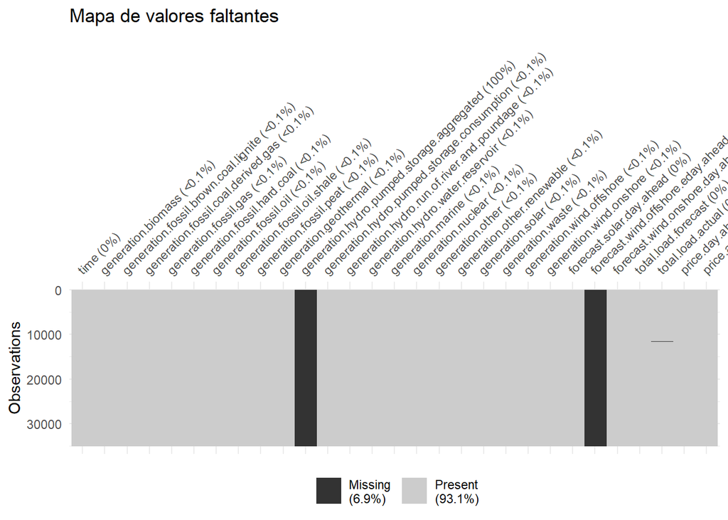

```r
naniar::vis_miss(df, warn_large_data = FALSE) + ggtitle("Mapa de valores faltantes")
```

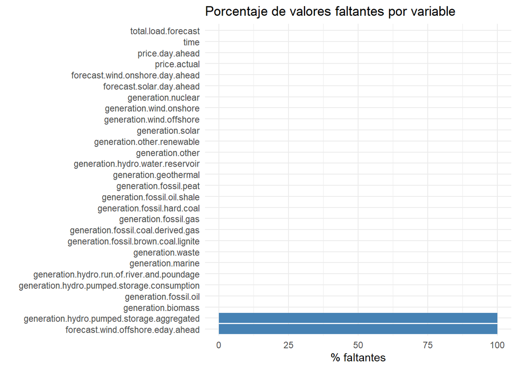

```r
library(tidyr)

missing_pct <- df %>% summarise_all(~mean(is.na(.))*100) %>% gather(key = "total.load.actual", value = "pct_missing")
ggplot(missing_pct, aes(x = reorder(total.load.actual, -pct_missing), y = pct_missing)) +
  geom_bar(stat = "identity", fill = "steelblue") +
  coord_flip() +
  labs(title = "Porcentaje de valores faltantes por variable", y = "% faltantes", x = "") +
  theme_minimal()
```

### 3. Tratamiento de valores faltantes

Se eliminan columnas con todos los valores NA.

```r
library(dplyr)
library(naniar)
library(tidyr)
library(ggplot2)

# Total filas
total_filas <- nrow(df)

# Función para tratar valores faltantes según cantidad
tratar_na <- function(data) {
  na_counts <- sapply(data, function(x) sum(is.na(x)))

  # Columnas a eliminar (más faltantes que filas)
  cols_eliminar <- names(na_counts[na_counts >= total_filas])

  # Columnas para imputar con media (faltantes entre 1 y 100)
  cols_imputar <- names(na_counts[na_counts > 0 & na_counts <= 100])

  # Eliminar columnas con muchos NA
  if(length(cols_eliminar) > 0) {
    data <- data %>% select(-all_of(cols_eliminar))
    message("Columnas eliminadas por exceso de NA: ", paste(cols_eliminar, collapse = ", "))
  }

  # Imputar con media columnas con pocos NA
  for(col in cols_imputar) {
    if(is.numeric(data[[col]])) {
      media <- mean(data[[col]], na.rm = TRUE)
      data[[col]][is.na(data[[col]])] <- media
      message("Imputados NA con media en columna: ", col)
    } else {
      message("Columna ", col, " no es numérica, no se imputó.")
    }
  }

  return(data)
}

# Aplicar función al dataframe
df_limpio <- tratar_na(df)
```

```
## Columnas eliminadas por exceso de NA: generation.hydro.pumped.storage.aggregated, forecast.wind.offshore.eday.ahead
```

```
## Imputados NA con media en columna: generation.biomass
```

```
## Imputados NA con media en columna: generation.fossil.brown.coal.lignite
```

```
## Imputados NA con media en columna: generation.fossil.coal.derived.gas
```

```
## Imputados NA con media en columna: generation.fossil.gas
```

```
## Imputados NA con media en columna: generation.fossil.hard.coal
```

```
## Imputados NA con media en columna: generation.fossil.oil
```

```
## Imputados NA con media en columna: generation.fossil.oil.shale
```

```
## Imputados NA con media en columna: generation.fossil.peat
```

```
## Imputados NA con media en columna: generation.geothermal
```

```
## Imputados NA con media en columna: generation.hydro.pumped.storage.consumption
```

```
## Imputados NA con media en columna: generation.hydro.run.of.river.and.poundage
```

```
## Imputados NA con media en columna: generation.hydro.water.reservoir
```

```
## Imputados NA con media en columna: generation.marine
```

```
## Imputados NA con media en columna: generation.nuclear
```

```
## Imputados NA con media en columna: generation.other
```

```
## Imputados NA con media en columna: generation.other.renewable
```

```
## Imputados NA con media en columna: generation.solar
```

```
## Imputados NA con media en columna: generation.waste
```

```
## Imputados NA con media en columna: generation.wind.offshore
```

```
## Imputados NA con media en columna: generation.wind.onshore
```

```
## Imputados NA con media en columna: total.load.actual
```

Ver resumen después del tratamiento

```r
summary_na_post <- df_limpio %>% summarise_all(~sum(is.na(.)))
print(summary_na_post)
```

```
##   time generation.biomass generation.fossil.brown.coal.lignite
## 1    0                  0                                    0
##   generation.fossil.coal.derived.gas generation.fossil.gas
## 1                                  0                     0
##   generation.fossil.hard.coal generation.fossil.oil generation.fossil.oil.shale
## 1                           0                     0                           0
##   generation.fossil.peat generation.geothermal
## 1                      0                     0
##   generation.hydro.pumped.storage.consumption
## 1                                           0
##   generation.hydro.run.of.river.and.poundage generation.hydro.water.reservoir
## 1                                          0                                0
##   generation.marine generation.nuclear generation.other
## 1                 0                  0                0
##   generation.other.renewable generation.solar generation.waste
## 1                          0                0                0
##   generation.wind.offshore generation.wind.onshore forecast.solar.day.ahead
## 1                        0                       0                        0
##   forecast.wind.onshore.day.ahead total.load.forecast total.load.actual
## 1                               0                   0                 0
##   price.day.ahead price.actual
## 1               0            0
```

Visualización de valores faltantes tras limpieza

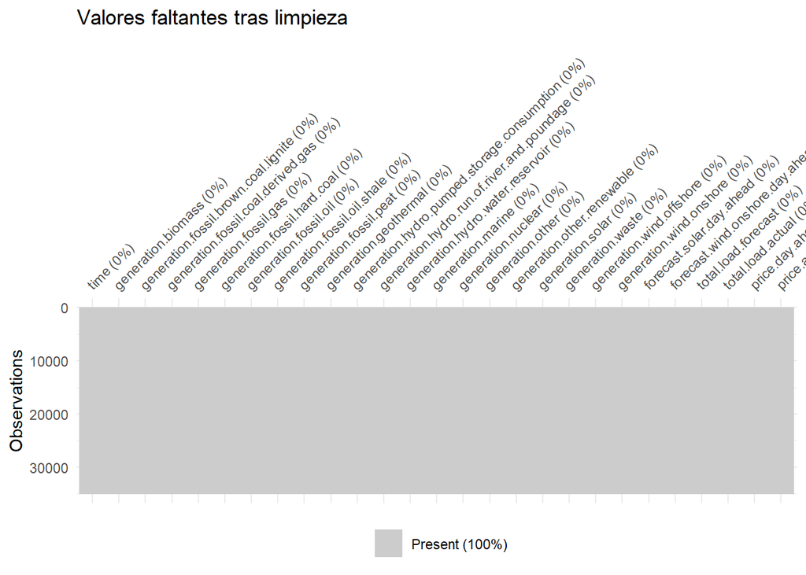

```r
naniar::vis_miss(df_limpio, warn_large_data = FALSE) + ggtitle("Valores faltantes tras limpieza")
```

```r
summary(df_limpio)
```

```
##      time           generation.biomass generation.fossil.brown.coal.lignite
##  Length:35064       Min.   :  0.0      Min.   :  0.0
##  Class :character   1st Qu.:333.0      1st Qu.:  0.0
##  Mode  :character   Median :367.0      Median :509.0
##                     Mean   :383.5      Mean   :448.1
##                     3rd Qu.:433.0      3rd Qu.:757.0
##                     Max.   :592.0      Max.   :999.0
##  generation.fossil.coal.derived.gas generation.fossil.gas
##  Min.   :0                          Min.   :    0
##  1st Qu.:0                          1st Qu.: 4127
##  Median :0                          Median : 4971
##  Mean   :0                          Mean   : 5623
##  3rd Qu.:0                          3rd Qu.: 6428
##  Max.   :0                          Max.   :20034
##  generation.fossil.hard.coal generation.fossil.oil generation.fossil.oil.shale
##  Min.   :   0                Min.   :  0.0         Min.   :0
##  1st Qu.:2529                1st Qu.:263.0         1st Qu.:0
##  Median :4473                Median :300.0         Median :0
##  Mean   :4256                Mean   :298.3         Mean   :0
##  3rd Qu.:5837                3rd Qu.:330.0         3rd Qu.:0
##  Max.   :8359                Max.   :449.0         Max.   :0
##  generation.fossil.peat generation.geothermal
##  Min.   :0              Min.   :0
##  1st Qu.:0              1st Qu.:0
##  Median :0              Median :0
##  Mean   :0              Mean   :0
##  3rd Qu.:0              3rd Qu.:0
##  Max.   :0              Max.   :0
##  generation.hydro.pumped.storage.consumption
##  Min.   :   0.0
##  1st Qu.:   0.0
##  Median :  68.0
##  Mean   : 475.6
##  3rd Qu.: 615.0
##  Max.   :4523.0
##  generation.hydro.run.of.river.and.poundage generation.hydro.water.reservoir
##  Min.   :   0.0                             Min.   :   0
##  1st Qu.: 637.0                             1st Qu.:1078
##  Median : 906.0                             Median :2165
##  Mean   : 972.1                             Mean   :2605
```

[output cut: 22 more lines]

```
##  Max.   :0                Max.   :17436           Max.   :5836
##  forecast.wind.onshore.day.ahead total.load.forecast total.load.actual
##  Min.   :  237                   Min.   :18105       Min.   :18041
##  1st Qu.: 2979                   1st Qu.:24794       1st Qu.:24810
##  Median : 4855                   Median :28906       Median :28894
##  Mean   : 5471                   Mean   :28712       Mean   :28697
##  3rd Qu.: 7353                   3rd Qu.:32263       3rd Qu.:32186
##  Max.   :17430                   Max.   :41390       Max.   :41015
##  price.day.ahead   price.actual
##  Min.   :  2.06   Min.   :  9.33
##  1st Qu.: 41.49   1st Qu.: 49.35
##  Median : 50.52   Median : 58.02
##  Mean   : 49.87   Mean   : 57.88
##  3rd Qu.: 60.53   3rd Qu.: 68.01
##  Max.   :101.99   Max.   :116.80
```

### 4. Transformación de la columna de fecha y hora

```r
library(dplyr)
library(lubridate)
# Suponiendo que df$time está en formato texto, primero convertir a POSIXct
df_limpio <- df_limpio %>%
  mutate(
    time = ymd_hms(time),  # se convierte a fecha-hora (ajusta formato si es necesario)
    fecha = format(time, "%d-%m-%Y"),           # día-mes-año
    hora = format(time, "%H:%M"),                # hora:minutos
    dia_semana = wday(time, label = TRUE, abbr = FALSE, week_start = 1),  # día de la semana (lunes=1)
    mes = month(time, label = TRUE, abbr = FALSE)  # mes con nombre completo
  )

df_limpio <- df_limpio %>%

  # Eliminar columna time
  select(-time) %>%

  # Reordenar columnas poniendo primero las nuevas
  select(fecha, hora, dia_semana, mes, everything())

head(df_limpio)
```

```
##        fecha  hora dia_semana       mes generation.biomass
## 1 31-12-2014 23:00  miércoles diciembre                447
## 2 01-01-2015 00:00     jueves     enero                449
## 3 01-01-2015 01:00     jueves     enero                448
## 4 01-01-2015 02:00     jueves     enero                438
## 5 01-01-2015 03:00     jueves     enero                428
## 6 01-01-2015 04:00     jueves     enero                410
##   generation.fossil.brown.coal.lignite generation.fossil.coal.derived.gas
## 1                                  329                                  0
## 2                                  328                                  0
## 3                                  323                                  0
## 4                                  254                                  0
## 5                                  187                                  0
## 6                                  178                                  0
##   generation.fossil.gas generation.fossil.hard.coal generation.fossil.oil
```

[output cut: 62 more lines]

### 5. Renombrado de columnas al español

Se renombran columnas técnicas a nombres más legibles en español

```r
df_limpio <- df_limpio %>%
  rename(
    fecha = fecha,
    hora = hora,
    dia_semana = dia_semana,
    mes = mes,
    generacion_con_biomasa = generation.biomass,
    generacion_con_carbon = generation.fossil.brown.coal.lignite,
    generacion_con_gas_derivado_carbon = generation.fossil.coal.derived.gas,
    generacion_con_gas_natural = generation.fossil.gas,
    generacion_con_carbon_duro = generation.fossil.hard.coal,
    generacion_con_petroleo = generation.fossil.oil,
    generacion_con_petroleo_esquisto = generation.fossil.oil.shale,
    turba = generation.fossil.peat,
    generacion_geotermica = generation.geothermal,
    energia_consumida_bateria = generation.hydro.pumped.storage.consumption,
    generacion_hidro_corriente = generation.hydro.run.of.river.and.poundage,
    generacion_hidro_embalse = generation.hydro.water.reservoir,
    generacion_marina = generation.marine,
    generacion_nuclear = generation.nuclear,
    otras = generation.other,
    renovables_otras = generation.other.renewable,
    generacion_solar = generation.solar,
    generacion_con_residuos = generation.waste,
    generacion_eolica_offshore = generation.wind.offshore,
    generacion_eolica_onshore = generation.wind.onshore,
    pronostico_solar_dia_siguiente = forecast.solar.day.ahead,
    pronostico_eolica_onshore_dia_siguiente = forecast.wind.onshore.day.ahead,
    carga_total_pronosticada = total.load.forecast,
    carga_total_real = total.load.actual,
    precio_dia_siguiente = price.day.ahead,
    precio_real = price.actual
  )

head(df_limpio)
```

```
##        fecha  hora dia_semana       mes generacion_con_biomasa
## 1 31-12-2014 23:00  miércoles diciembre                    447
## 2 01-01-2015 00:00     jueves     enero                    449
## 3 01-01-2015 01:00     jueves     enero                    448
## 4 01-01-2015 02:00     jueves     enero                    438
## 5 01-01-2015 03:00     jueves     enero                    428
## 6 01-01-2015 04:00     jueves     enero                    410
##   generacion_con_carbon generacion_con_gas_derivado_carbon
## 1                   329                                  0
## 2                   328                                  0
## 3                   323                                  0
## 4                   254                                  0
## 5                   187                                  0
## 6                   178                                  0
##   generacion_con_gas_natural generacion_con_carbon_duro generacion_con_petroleo
```

[output cut: 48 more lines]

### 6. Eliminación de columnas con todos ceros

Se eliminan columnas que no aportan información (todos ceros).

```r
df_limpio <- df_limpio[, colSums(df_limpio != 0, na.rm = TRUE) > 0]

head(df_limpio)
```

```
##        fecha  hora dia_semana       mes generacion_con_biomasa
## 1 31-12-2014 23:00  miércoles diciembre                    447
## 2 01-01-2015 00:00     jueves     enero                    449
## 3 01-01-2015 01:00     jueves     enero                    448
## 4 01-01-2015 02:00     jueves     enero                    438
## 5 01-01-2015 03:00     jueves     enero                    428
## 6 01-01-2015 04:00     jueves     enero                    410
##   generacion_con_carbon generacion_con_gas_natural generacion_con_carbon_duro
## 1                   329                       4844                       4821
## 2                   328                       5196                       4755
## 3                   323                       4857                       4581
## 4                   254                       4314                       4131
## 5                   187                       4130                       3840
## 6                   178                       4038                       3590
##   generacion_con_petroleo energia_consumida_bateria generacion_hidro_corriente
```

[output cut: 34 more lines]

### 7. Creación de columna datetime y ordenación

Se crea una columna datetime combinando fecha y hora.

```r
library(dplyr)
library(lubridate)
library(ggplot2)
library(forecast)
# Crear columna datetime en formato POSIXct
df_limpio <- df_limpio %>%
  mutate(
    datetime = dmy_hm(paste(fecha, hora))  # dmy_hm para formato "día-mes-año hora:min"
  ) %>%
  arrange(datetime)  # ordenar por fecha/hora
```

```r
library(ggplot2)
library(dplyr)
library(lubridate)
library(tidyr)

# Convertir fecha y hora a datetime
df_limpio <- df_limpio %>%
  mutate(datetime = dmy_hm(paste(fecha, hora)),
         dia_semana = factor(dia_semana,
                             levels = c("lunes", "martes", "miércoles", "jueves", "viernes", "sábado", "domingo")),
         mes = factor(mes, levels = tolower(month.name)))

library(dplyr)
library(lubridate)

df_limpio <- df_limpio %>%
  mutate(
    mes = tolower(month(datetime, label = TRUE, abbr = FALSE)),  # extrae nombre del mes en minúsculas
    mes = factor(mes, levels = tolower(month.name))              # factor ordenado de enero a diciembre
  )
```

### 8. Análisis visual de patrones, tendencias y ciclos

Se grafican series temporales para diferentes fuentes de generación.

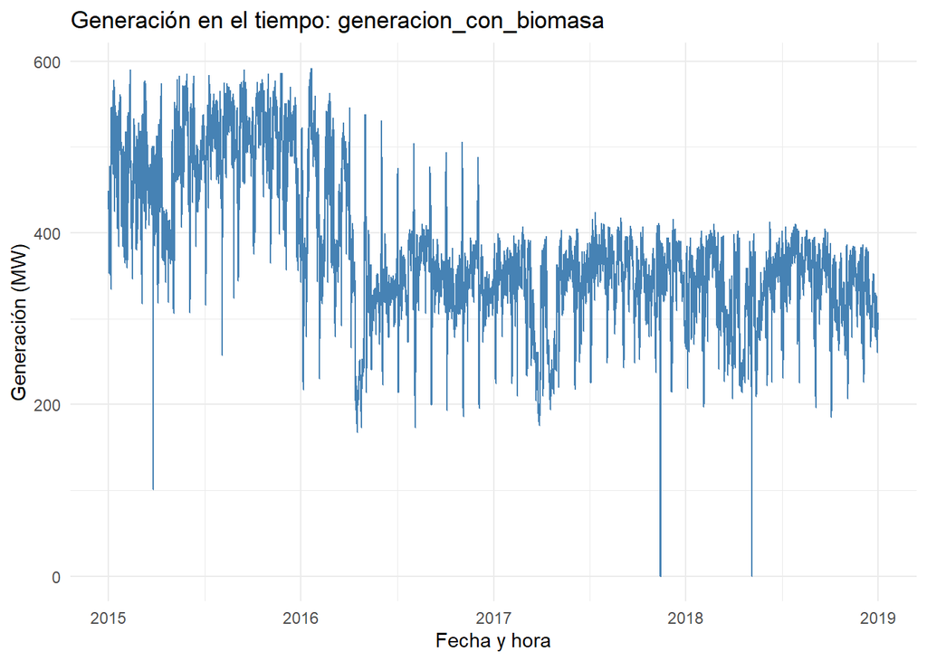

```
## Presiona Enter para ver el siguiente gráfico...
```

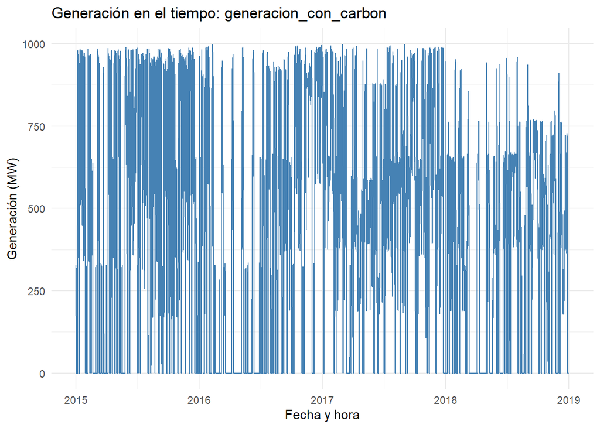

```
## Presiona Enter para ver el siguiente gráfico...
```

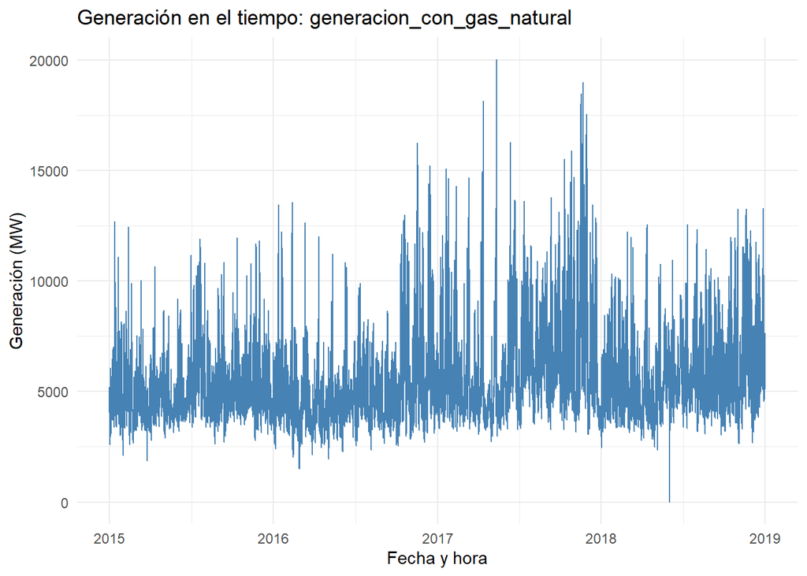

```
## Presiona Enter para ver el siguiente gráfico...
```

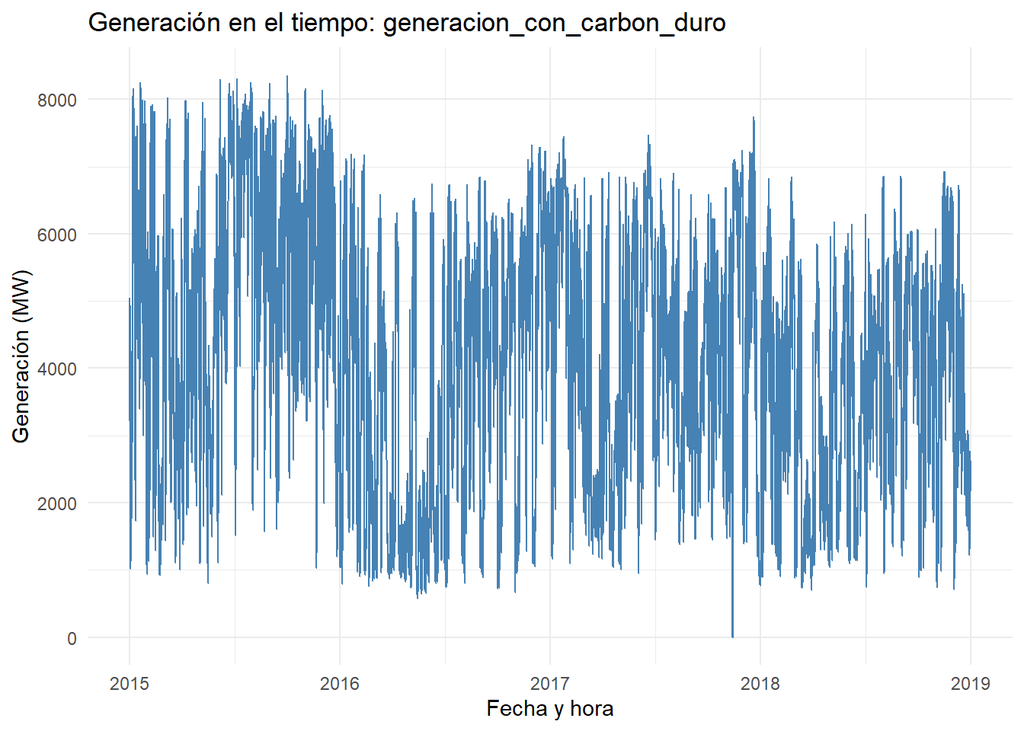

```
## Presiona Enter para ver el siguiente gráfico...
```

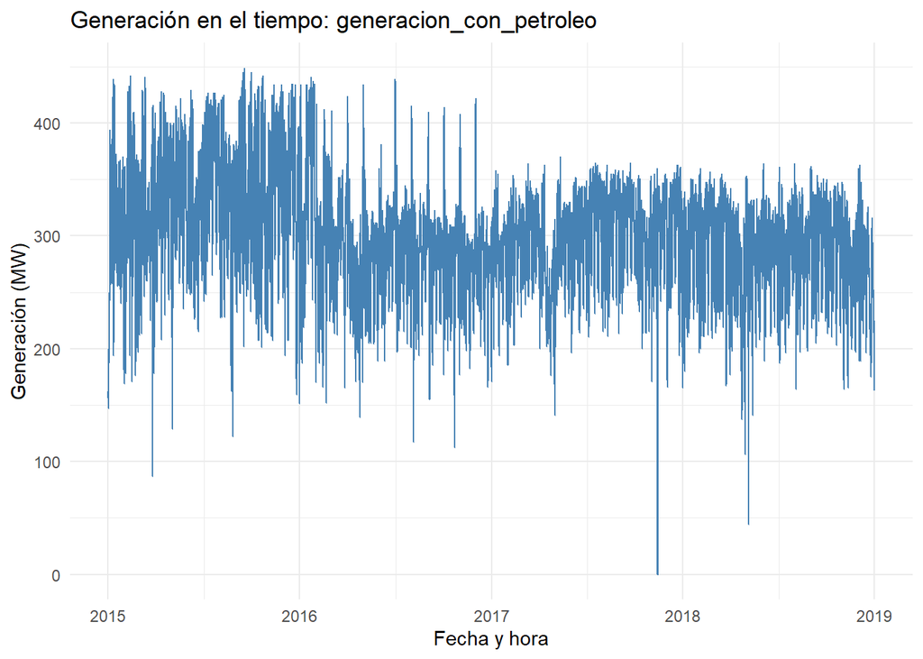

```
## Presiona Enter para ver el siguiente gráfico...
```

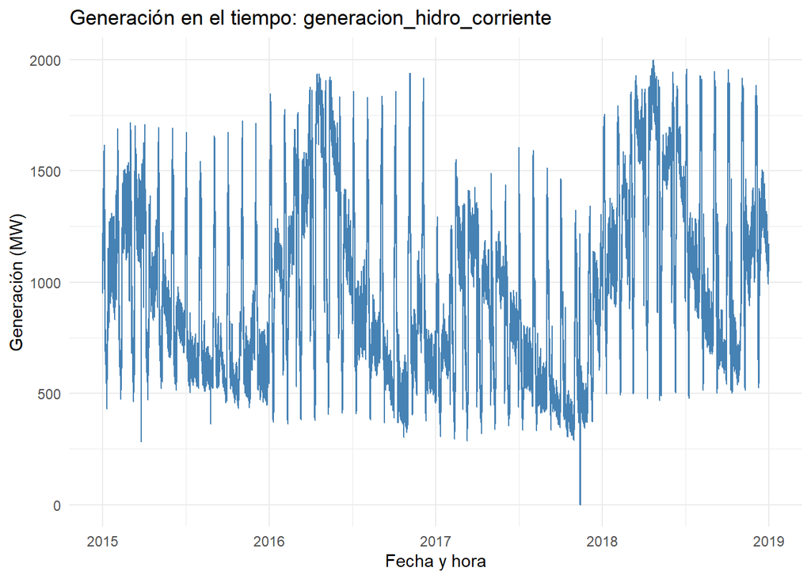

```
## Presiona Enter para ver el siguiente gráfico...
```

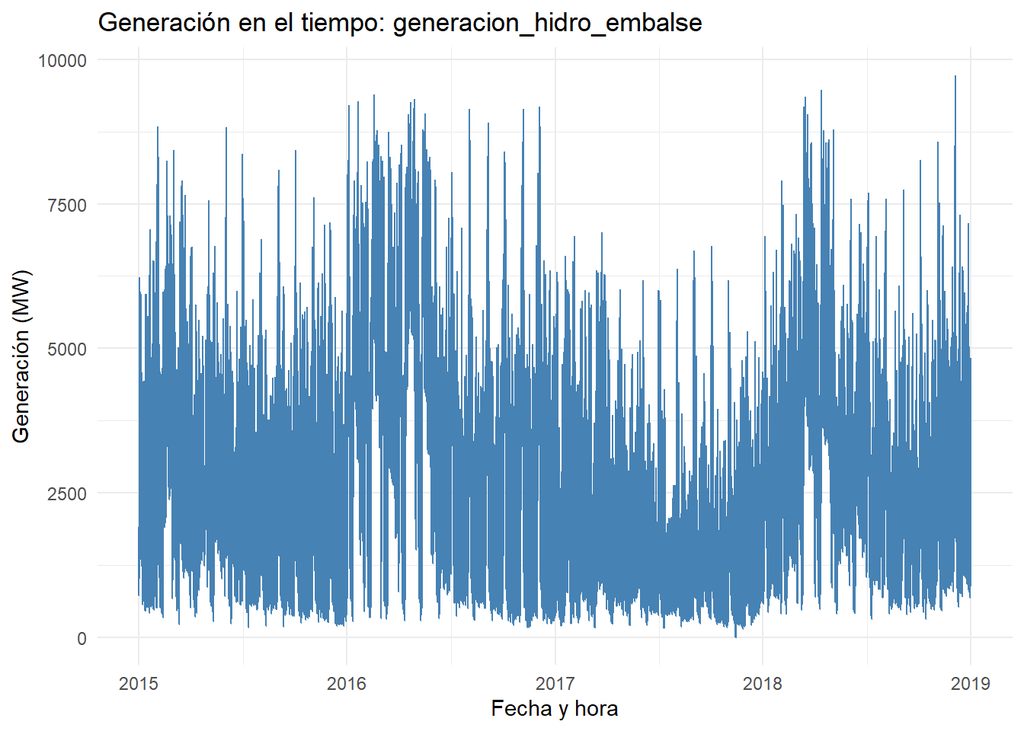

```
## Presiona Enter para ver el siguiente gráfico...
```

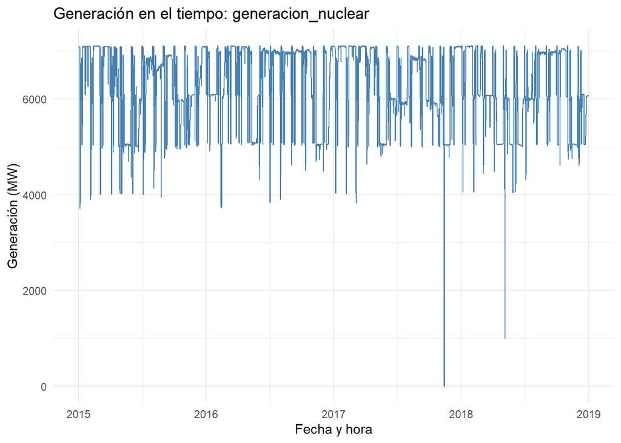

```
## Presiona Enter para ver el siguiente gráfico...
```

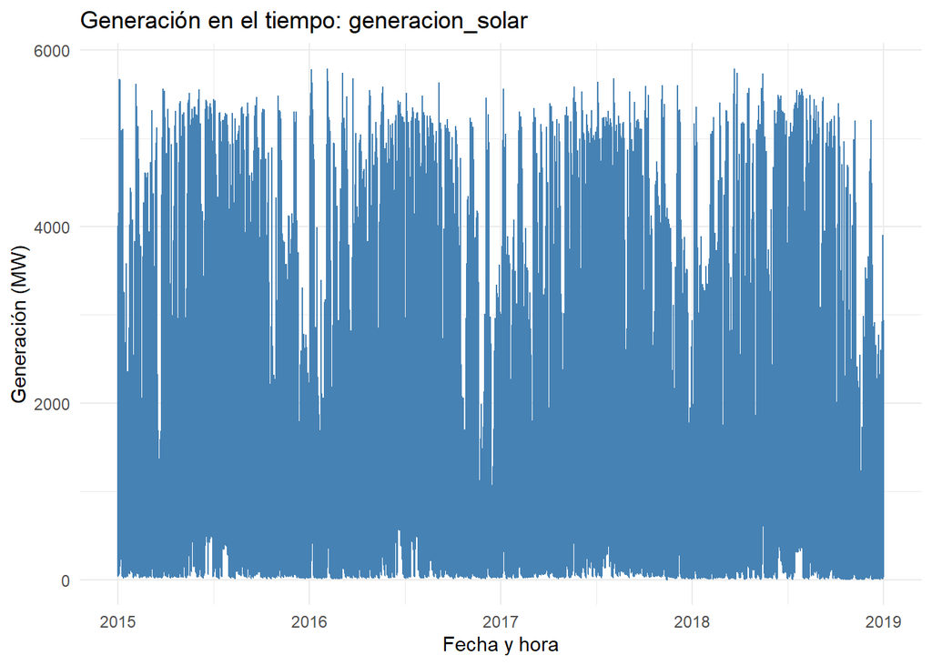

```
## Presiona Enter para ver el siguiente gráfico...
```

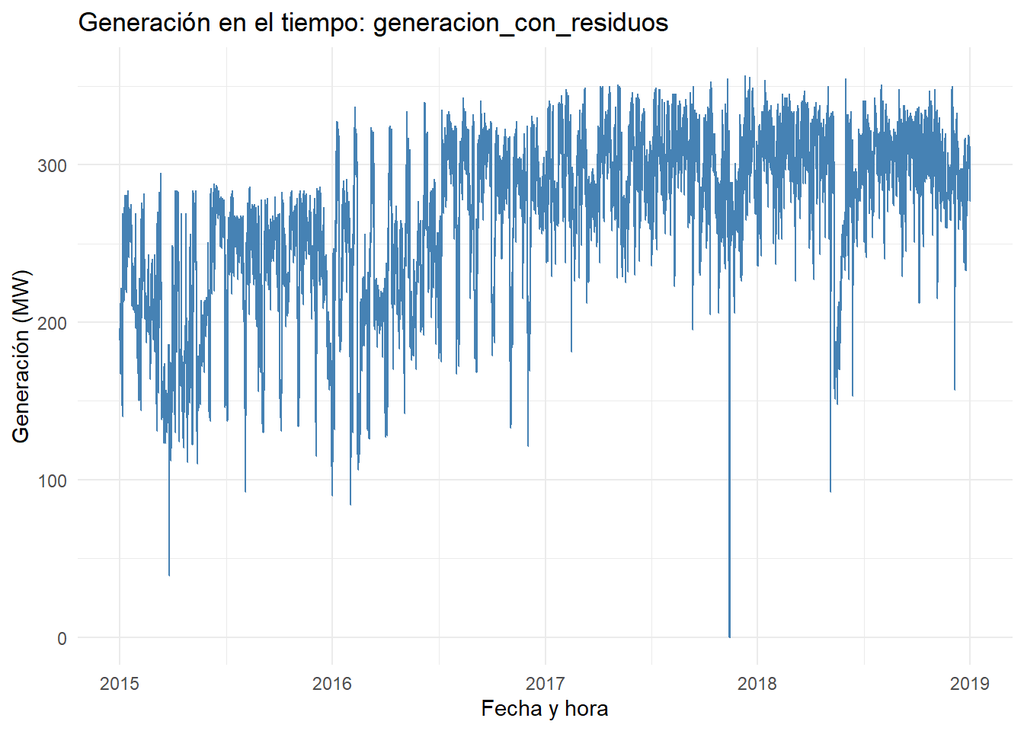

```
## Presiona Enter para ver el siguiente gráfico...
```

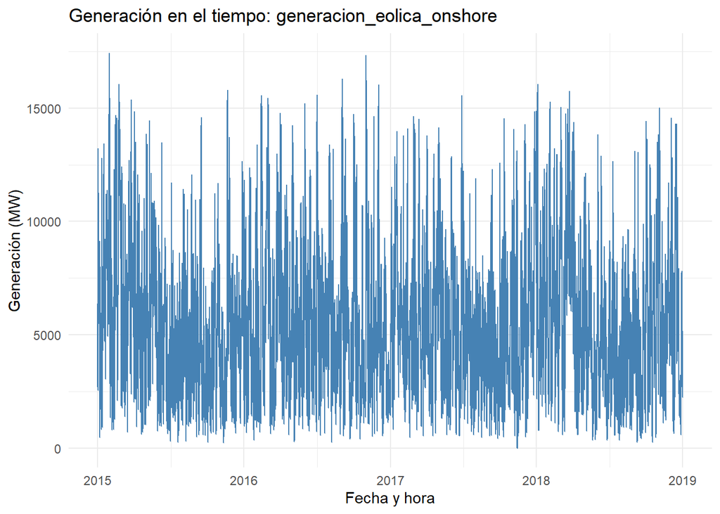

```
## Presiona Enter para ver el siguiente gráfico...
```

```r
library(ggplot2)
library(dplyr)
library(tidyr)
library(lubridate)

# Vector con las columnas de generación que quieres graficar
fuentes <- c("generacion_con_biomasa", "generacion_con_carbon", "generacion_con_gas_natural",
             "generacion_con_carbon_duro", "generacion_con_petroleo",
             "generacion_hidro_corriente", "generacion_hidro_embalse", "generacion_nuclear",
             "generacion_solar", "generacion_con_residuos", "generacion_eolica_onshore")

# Asegúrate que datetime está en formato POSIXct
df_limpio <- df_limpio %>%
  mutate(datetime = as.POSIXct(datetime))

for (fuente in fuentes) {
  # Crear gráfico para la fuente actual
  p <- ggplot(df_limpio, aes_string(x = "datetime", y = fuente)) +
    geom_line(color = "steelblue") +
    labs(title = paste("Generación en el tiempo:", fuente),
         x = "Fecha y hora",
         y = "Generación (MW)") +
    theme_minimal()

  print(p)

  # Esperar a que el usuario presione Enter para continuar
  cat("Presiona Enter para ver el siguiente gráfico...")
  invisible(readline())
}
```

Se hacen boxplots por día de la semana.

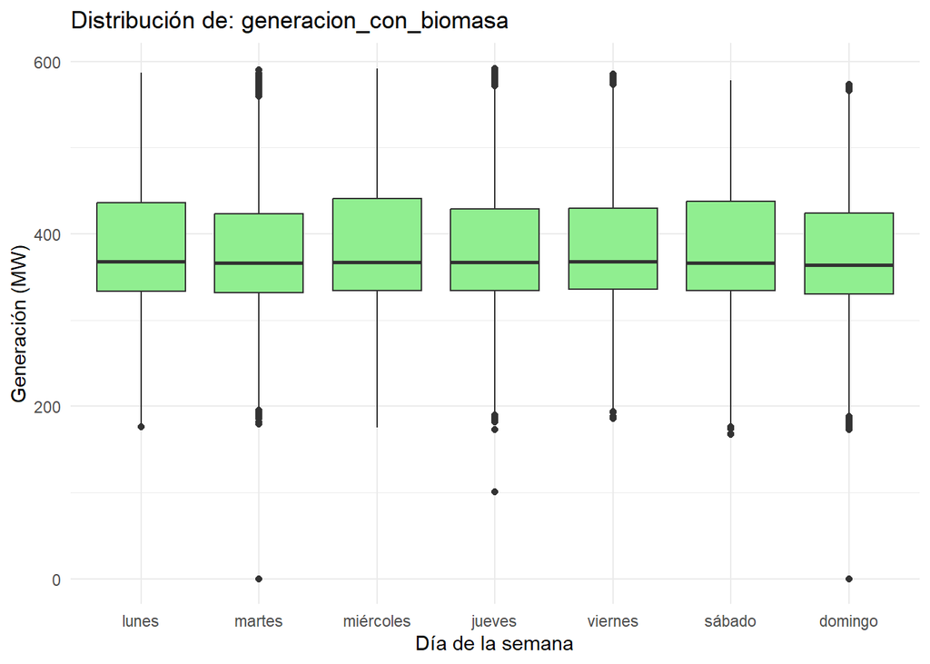

```
## Presiona Enter para ver el siguiente boxplot...
```

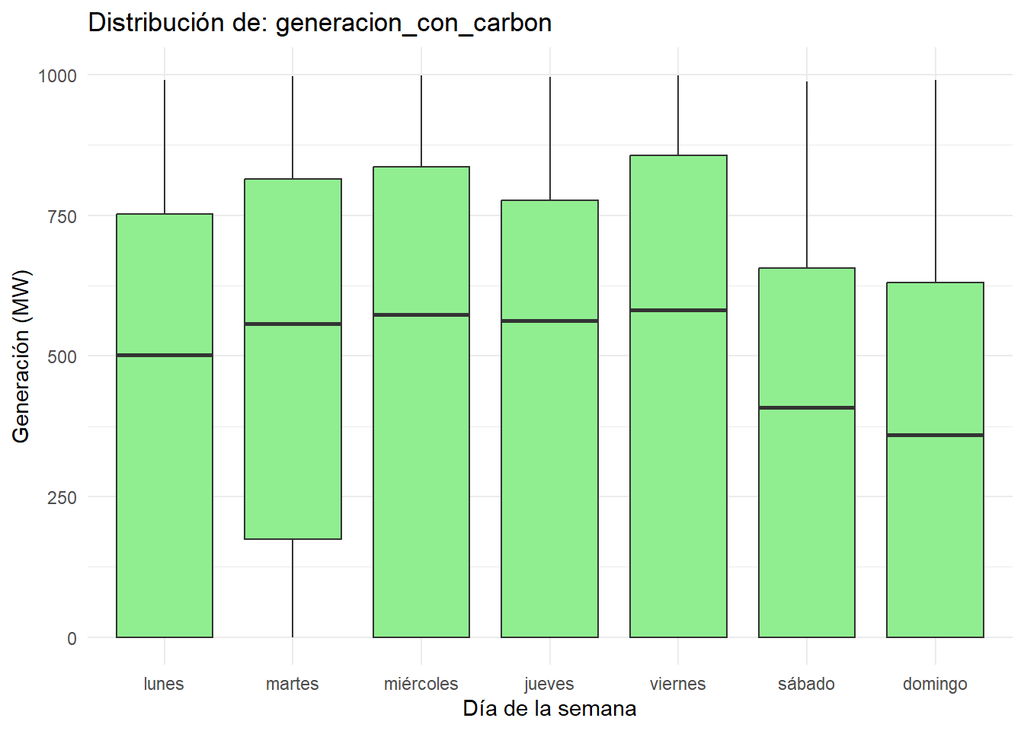

```
## Presiona Enter para ver el siguiente boxplot...
```

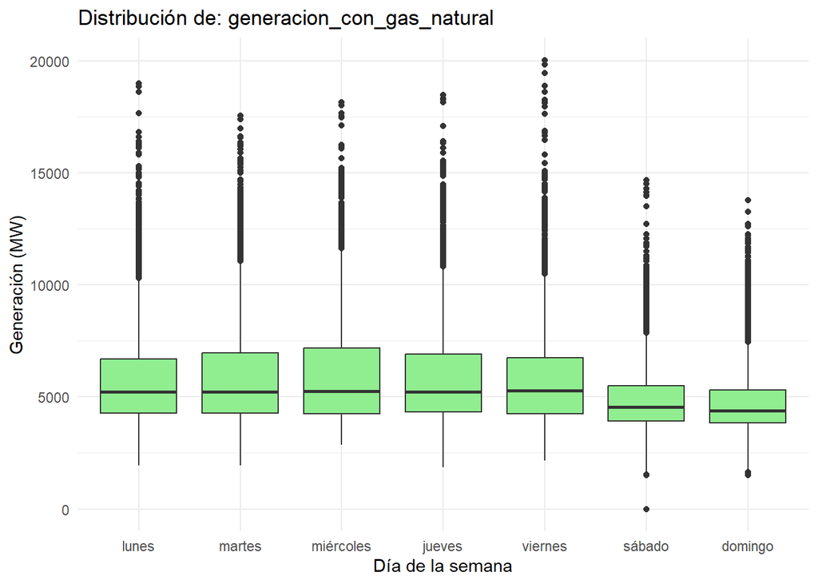

```
## Presiona Enter para ver el siguiente boxplot...
```

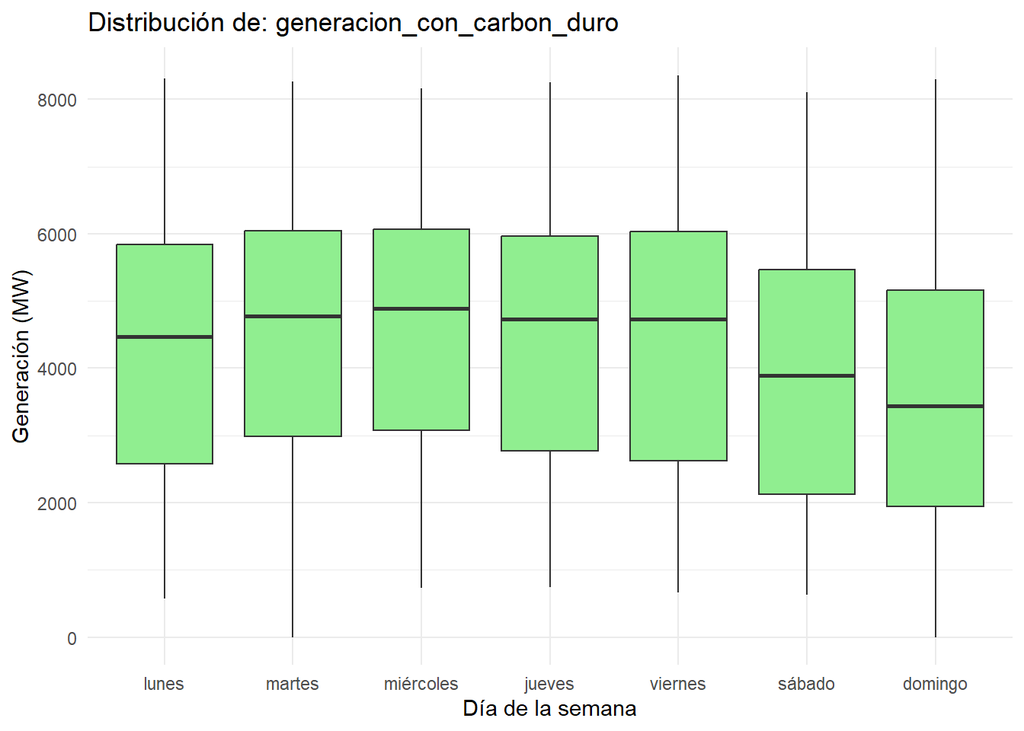

```
## Presiona Enter para ver el siguiente boxplot...
```

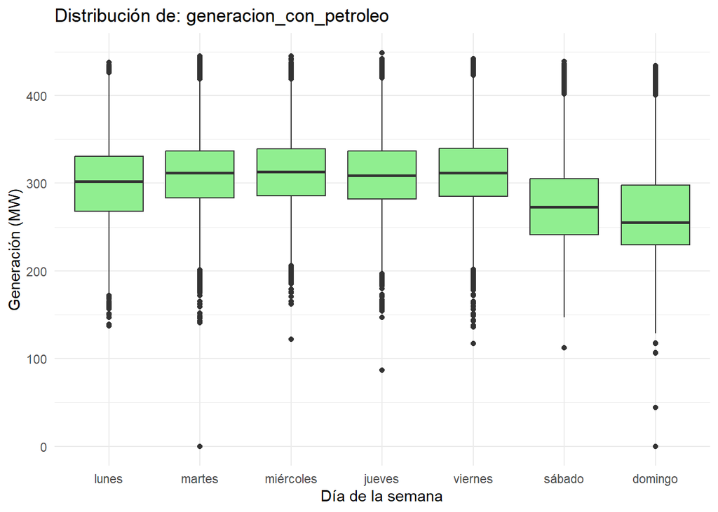

```
## Presiona Enter para ver el siguiente boxplot...
```

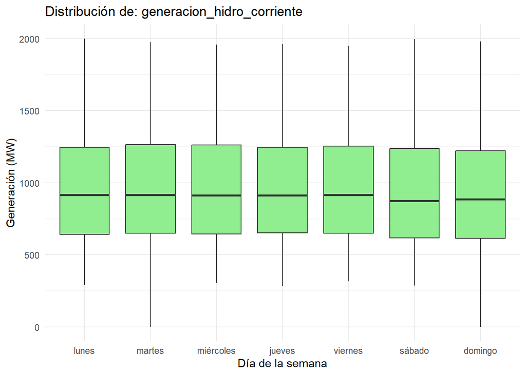

```
## Presiona Enter para ver el siguiente boxplot...
```

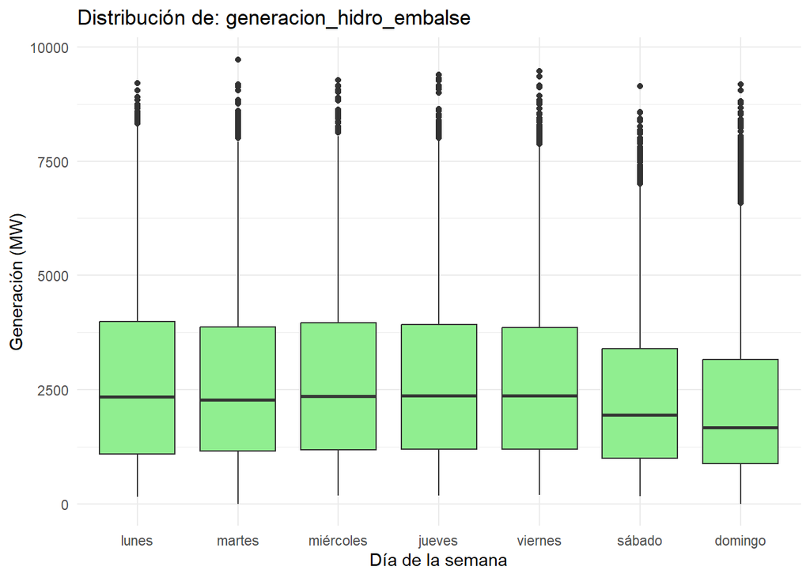

```
## Presiona Enter para ver el siguiente boxplot...
```

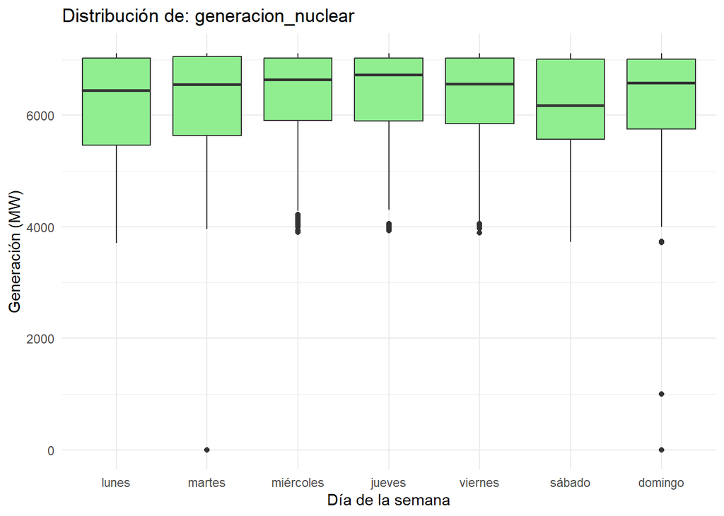

```
## Presiona Enter para ver el siguiente boxplot...
```

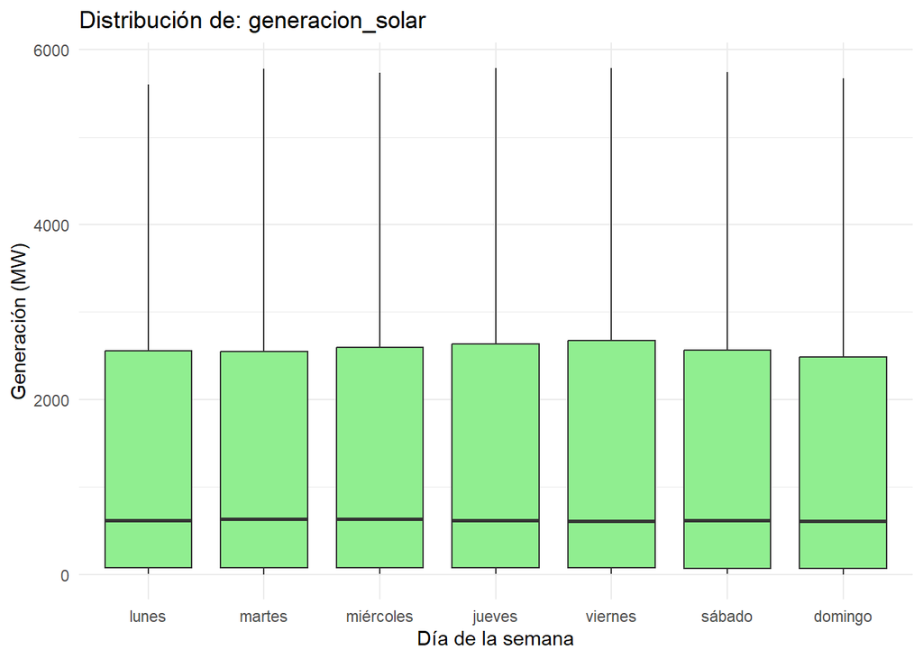

```
## Presiona Enter para ver el siguiente boxplot...
```

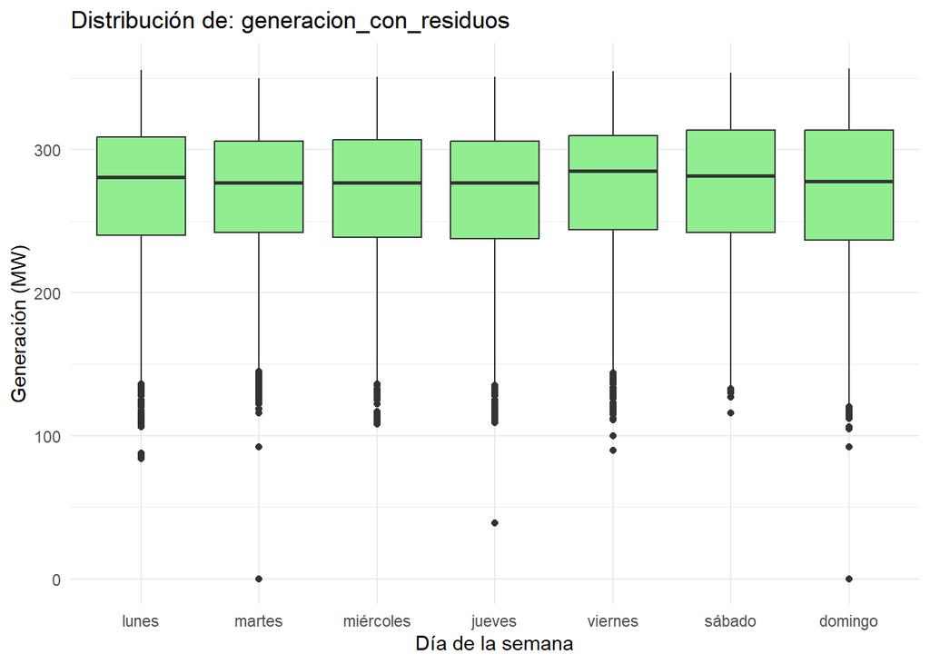

```
## Presiona Enter para ver el siguiente boxplot...
```

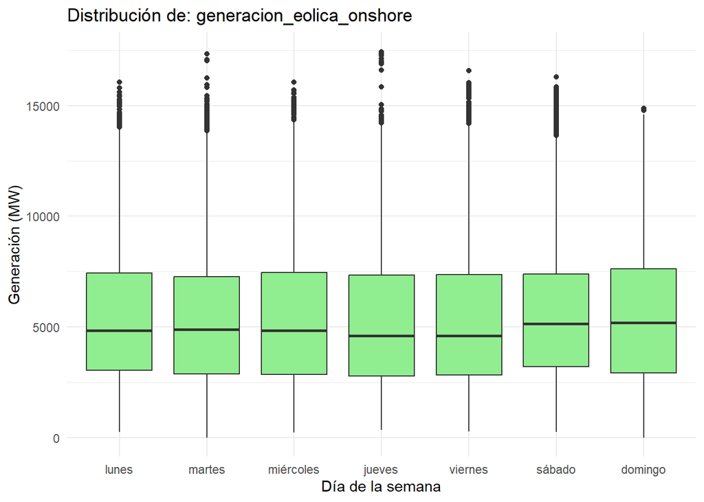

```
## Presiona Enter para ver el siguiente boxplot...
```

```r
for (fuente in fuentes) {
  p <- ggplot(df_limpio, aes_string(x = "dia_semana", y = fuente)) +
    geom_boxplot(fill = "lightgreen") +
    labs(title = paste("Distribución de:", fuente),
         x = "Día de la semana",
         y = "Generación (MW)") +
    theme_minimal()

  print(p)

  cat("Presiona Enter para ver el siguiente boxplot...")
  invisible(readline())
}
```

Se crean heatmaps para generación promedio por hora y día.